# Tree Analysis

Joseph Crockett

### Homework Assignment 1

#### Objective Statement

Technological advances in LiDAR systems have both increased the accuracy and reduced cost in recent years, however, both system cost and labor required to process data is prohibitive at the biome-scale. Using LiDAR measurements of Sierra Nevada conifers, our objective is to determine, if any, the relationship between crown spread and tree height. A positive correlaton would inform a model that utilizes less costly remote sensing systems (i.e. Landsat/ NAIP) to estimate tree height from aerial images. From such a model, standing carbon can be estimated from conifer biomass (volumes).

### Code

```r
tree_data <- read.csv("~/Desktop/Documents/Writings/Spring 2016/ES 207/Labs/Lab1/Trees.csv",
    header = T)  #load LiDAR tree measurements into local environment data frame

dim(tree_data)  #Checking formatting of frame.
```

```
## [1] 176100      5
```

```r
str(tree_data)
```

```
## 'data.frame':    176100 obs. of  5 variables:
##  $ OBJECTID: int  1 2 3 4 5 6 7 8 9 10 ...
##  $ x       : num  707921 707921 708190 708546 707569 ...
##  $ y       : num  4333002 4333002 4333002 4333002 4333002 ...
##  $ z.m.    : num  2.01 2.01 12.6 42.29 15.63 ...
##  $ r.m.    : num  1.03 1.03 2.11 5.47 2.93 ...
```

```r
anyDuplicated(tree_data[, 2:5])  # Check for duplicated entries
```

```
## [1] 2
```

```r
# The formatting seems appropriate, but I will rename column
# names to avoid conflicts.
colnames(tree_data) <- c("OBJECTID", "xval", "yval", "zval",
    "rval")

save(tree_data, file = "~/Desktop/tree_data.rda")
```

```r
ncol(tree_data)  #running data diagnostics
```

```
## [1] 5
```

```r
nrow(tree_data)
```

```
## [1] 176100
```

```r
head(tree_data)
```

```
##   OBJECTID     xval    yval    zval     rval
## 1        1 707921.2 4333002  2.0061 1.032689
## 2        2 707921.2 4333002  2.0061 1.032689
## 3        3 708189.9 4333002 12.5996 2.113910
## 4        4 708546.1 4333002 42.2903 5.471469
## 5        5 707569.2 4333002 15.6254 2.930143
## 6        6 708935.7 4333002 13.4347 2.908795
```

```r
tail(tree_data)
```

```
##        OBJECTID     xval    yval    zval     rval
## 176095   176095 708708.2 4334600  5.2456 2.377610
## 176096   176096 708753.0 4334600  5.0028 1.589963
## 176097   176097 708753.0 4334600  5.0028 1.452385
## 176098   176098 708762.9 4334600 44.8285 2.970038
## 176099   176099 708817.8 4334600  8.1583 2.971006
## 176100   176100 708817.8 4334600  8.1583 2.971006
```

```r
summary(tree_data)  # shows mean, max, min, median, IQR, range, etc.
```

```
##     OBJECTID           xval             yval              zval
##  Min.   :     1   Min.   :707062   Min.   :4333002   Min.   : 2.000
##  1st Qu.: 44026   1st Qu.:707570   1st Qu.:4333401   1st Qu.: 6.155
##  Median : 88050   Median :707997   Median :4333765   Median :10.901
##  Mean   : 88050   Mean   :708017   Mean   :4333777   Mean   :13.910
##  3rd Qu.:132075   3rd Qu.:708471   3rd Qu.:4334154   3rd Qu.:17.776
##  Max.   :176100   Max.   :709000   Max.   :4334600   Max.   :73.927
##       rval
##  Min.   : 0.1847
##  1st Qu.: 1.5021
##  Median : 2.2416
##  Mean   : 2.5956
##  3rd Qu.: 3.3191
##  Max.   :12.0044
```

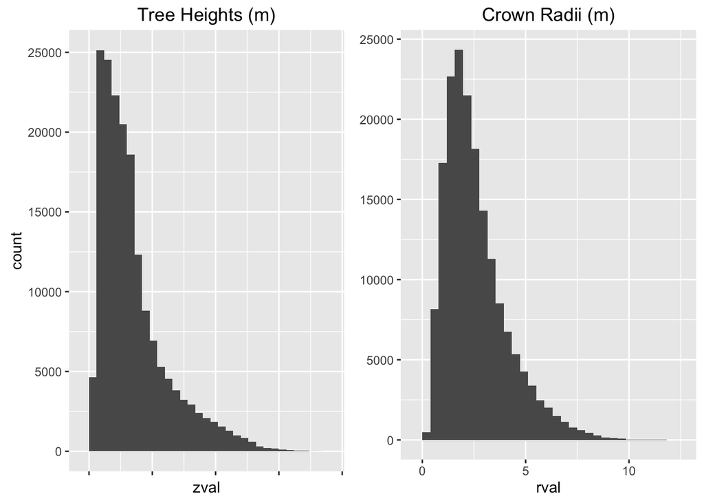

```r
library(ggplot2)  #plotting histograms using ggplot2, with a function to plot multiple graphs
library(gtable)
library(grid)
library(gridExtra)
library(ggExtra)

p1 <- ggplot(tree_data, aes(x = zval)) + geom_histogram() + theme(axis.text.x = element_blank()) +
    ggtitle("Tree Heights (m)")

p2 <- ggplot(tree_data, aes(x = rval)) + geom_histogram() + theme(axis.title.y = element_blank()) +
    ggtitle("Crown Radii (m)")

grid.arrange(p1, p2, nrow = 1, ncol = 2)
```

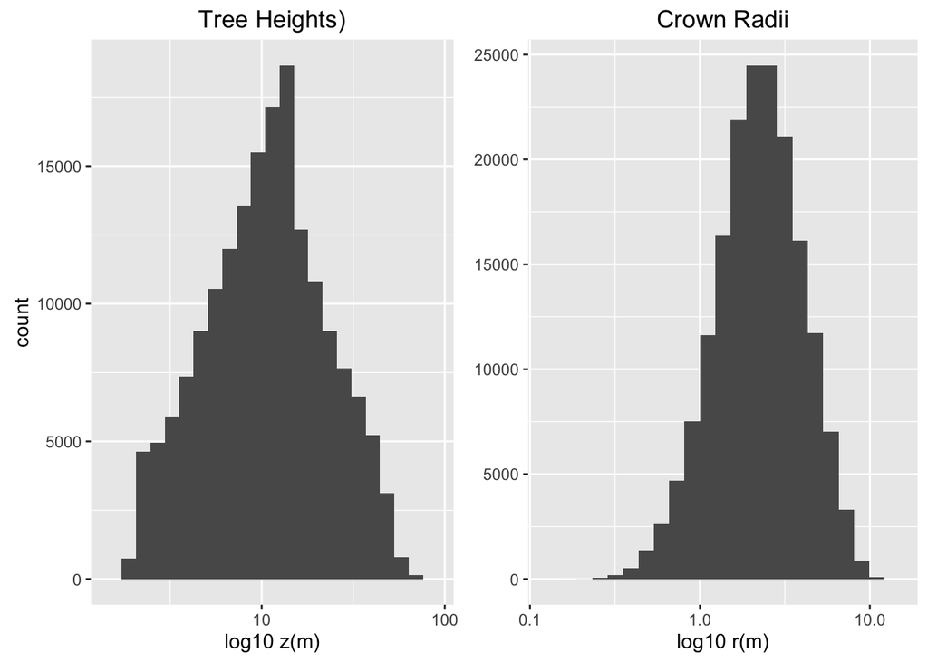

```r
p3 <- ggplot(tree_data, aes(x = zval)) + geom_histogram(bins = 20) +
    scale_x_log10() + labs(title = "Tree Heights)", x = "log10 z(m)",
    size = 0.5)

p4 <- ggplot(tree_data, aes(x = rval)) + geom_histogram(bins = 20) +
    scale_x_log10() + theme(axis.title.y = element_blank()) +
    labs(title = "Crown Radii", x = "log10 r(m)", size = 0.5)

grid.arrange(p3, p4, ncol = 2)
```

```r
# Log transformation gives us normal distribution for tree
# heights and crown radii.
```

Pearson Correlations

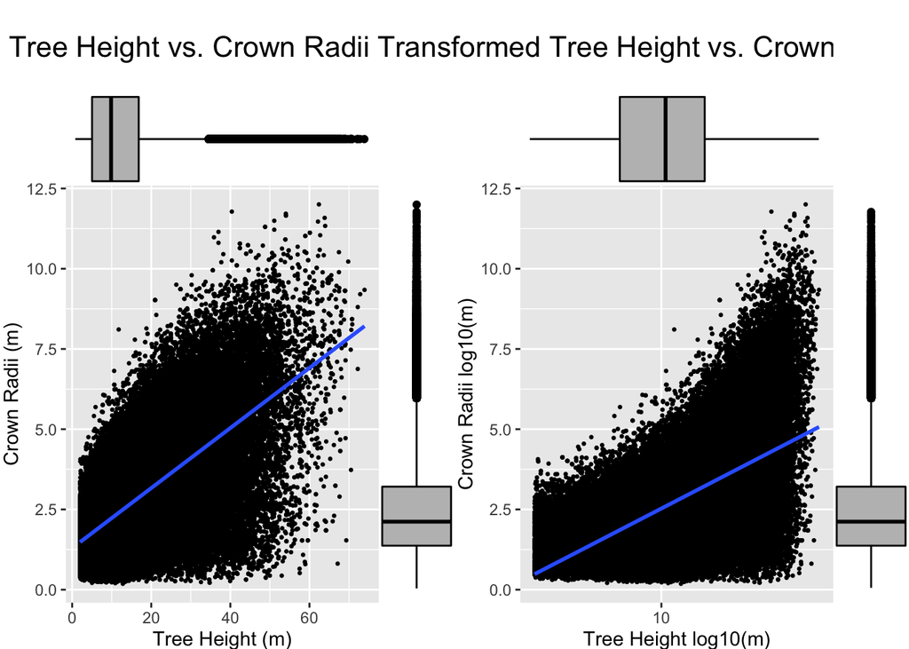

```r
p5 <- ggplot(data = tree_data, aes(x = zval, y = rval)) + geom_point(position = "jitter",
    size = 0.5) + geom_smooth(method = glm) + labs(title = "Tree Height vs. Crown Radii",
    x = "Tree Height (m)", y = "Crown Radii (m)")

p6 <- ggMarginal(p5, type = "boxplot")
p7 <- ggplot(data = tree_data, aes(x = zval, y = rval)) + geom_point(position = "jitter",
    size = 0.5) + geom_smooth(method = glm) + scale_x_log10() +
    labs(title = "Transformed Tree Height vs. Crown Radii", x = "Tree Height log10(m)",
        y = "Crown Radii log10(m)")

p8 <- ggMarginal(p7, type = "boxplot")
grid.arrange(p6, p8, ncol = 2, nrow = 1)
```

```r
# Test for correlation between Tree Height and Crown Radii An
# assumption of Pearson's correlation is that variables must
# be approximately normally distributed, so log
# transformation will ensure that this assumption is held.

cor.test(x = log10(tree_data[, 4]), y = log10(tree_data[, 5]),
    na.action = na.omit)
```

[output not shown]

```r
# Without assuming normality, we can use Spearman's rho test
# to test correlation between non-parametric variables

cor.test(x = tree_data[, 4], y = tree_data[, 5], na.action = na.omit,
    method = "spearman")
```

```
##
##  Spearman's rank correlation rho
##
## data:  tree_data[, 4] and tree_data[, 5]
## S = 3.4322e+14, p-value < 2.2e-16
## alternative hypothesis: true rho is not equal to 0
## sample estimates:
##       rho
## 0.6229113
```

```r
EDA <- function(x) {
    # x is a list of values
    min_tmp <- min(x, na.rm = T)
    max_tmp <- max(x, na.rm = T)
    mdn_tmp <- median(x, na.rm = T)
    mn_tmp <- mean(x, na.rm = T)
    rnge_tmp <- range(x, na.rm = T)
    sd_tmp <- sd(x, na.rm = T)
    cv_tmp <- (sd_tmp/mn_tmp) * 100
    print(paste("Minimum =", min_tmp, sep = " "))
    print(paste("Maximum =", max_tmp, sep = " "))
    print(paste("Median =", mdn_tmp, sep = " "))
    print(paste("Mean =", mn_tmp, sep = " "))
    print(rnge_tmp)
    print(paste("Standard Deviation =", sd_tmp, sep = " "))
    print(paste("Coefficient of Variance =", cv_tmp, sep = " "))

}
```

### Results

Distributions of tree height and crown radii are skewed right, thus we log transformed the data to better meet the assumptions of normality. Subsequent Spearman’s rho and Pearson’s product moment correlation tess indicated that correlation between height and radii exist with r-values of .623 and .598 respectively (p-value < 2.2e-16 and < 2.2e-16).